# Technology and Crime

CRIM 100 - FALL 2019

## Today’s Topics

- Technology and human behaviour
- Technology and criminal behaviour
- The deep web and the darknet

# Technology and human behaviour

## Worldwide access to technology

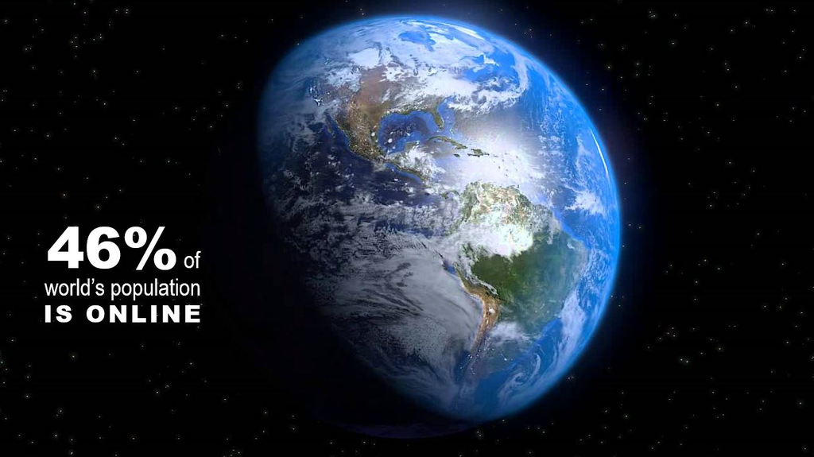

## Access to technology in Canada

[figure not shown]

## Technological advancements?

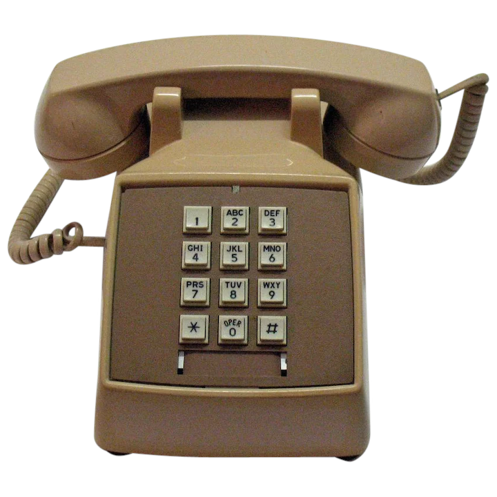

## Hello? Who is this? Hello??!!

[figure not shown]

## Extension theories of technology and human behaviour

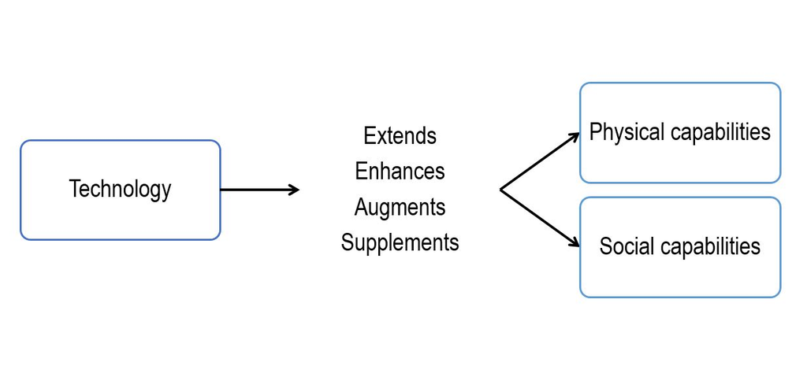

## How did automobiles affect human behaviour?

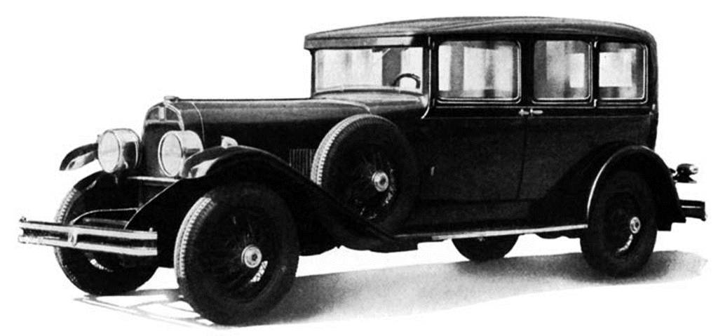

# Technology and criminal behaviour

## Basic technology and crime interaction

- *Technology-enabled offences:* traditional crimes facilitated by the use of technology (e.g., identity theft)
- *Technology-dependent offences:* crimes that exist because of technology (e.g., ransomware)

## Interaction between ICT and crime (Viano, 2017)

- “Ordinary” criminal offenses committed by means of information and communication technology (ICT).
- Crimes directed against the proper functioning of ICT systems
- Crimes against interests that are web-specific

## Typology of technology-facilited crimes

- *Techno-crime AS work:* crime opportunities provided by ICT and exploited by individuals as their source income.
- *Techno-crime AT work:* crime opportunities facilited by ICT during the course of an individual’s legitimate work.
- *Techno-crime AFTER work:* crime opportunities facilitated by ICT and exploited by individuals during their leisure time.

## Examples

- *Techno-crime AS work:* Internet fraud schemes, telemarketing fraud schemes, identity theft, credit card fraud, phishing for profit, internet sex crimes, sale of stolen data, internet piracy, etc.
- *Techno-crime AT work:* Embezzelment, money laundering, financial fraud, credit card fraud by employees, corporate espionage, theft/sale private information, spreading viruses or malicious code, etc.
- *Techno-crime AFTER work:* internet sex crimes, internet sex crimes, cyber-terrorism, hacking, illegal access to data, etc.

# The Deep Web and the darknet

## The Deep Web

“… refers to all online material, including the darknet and mainstream sites that is not indexed or accessible through serarch engines”

## The surface web, deep web and darknet

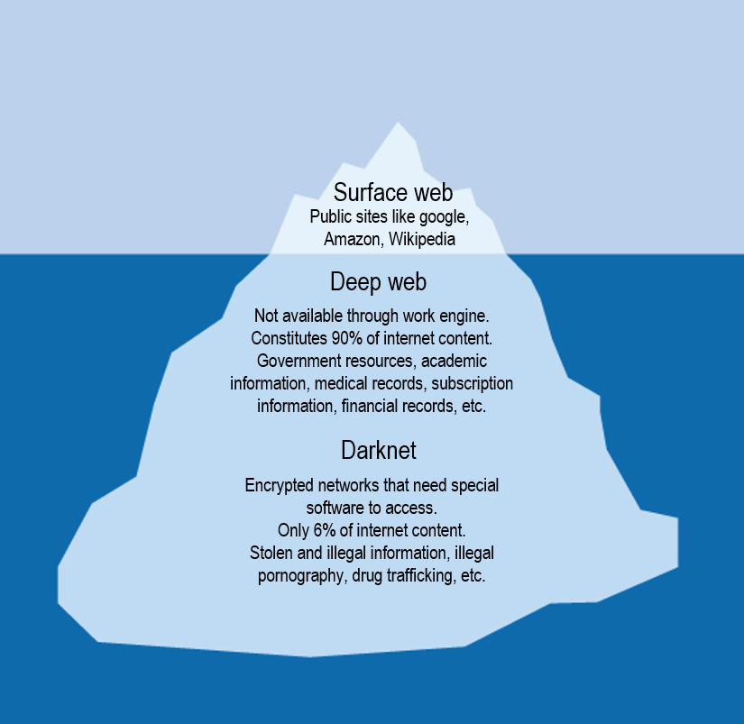

## The Darknet

- Designed to guarantee anonymity by the US Naval Research Laboratory
- Many types of users: criminals, criminal organizations, government workers, academics, terorrist organizations, whistle blowers, journalists, etc.
- Content not available through normal browsers
- .Onion websites
- TOR (The Onion Router)

## The Darknet and crime

- Market place for selling illicit commodities and services
  - Drugs
  - Stolen data
  - Illegal weapons
  - Sex trade
  - Illegal content
  - Murder for hire
  - Hacking
  - Cyber attacks
- Virtually undectectable
- Cryptocurrency for transactions

## Easiest Catch: Don’t Be Another Fish in the Dark Net

https://youtu.be/GEwmYk15ZcU

# Content review

## Key concepts

- Extension theories
- Technology-dependent offences
- Technology-enabled offences
- Viano’s (2017) types of interaction between ICT and crime
- Techno-crime AS work
- Techno-crime AT work
- Techno-crime AFTER work
- Surface web
- Deep web
- Darknet
- TOR